# Can R Notebooks help with reproducibility?

Av Ann Elisabeth Jacobsen og Heidi Marie Rolfsnes

September 2021

# Introduction

Problems with reproducibility and replications has been a hotly discussed topic in social science the last decade. In this short paper we will discuss if R Notebooks is a tool that can help researches to overcome these problems. We will start with a short description of R and R Notebooks, then define some important terms before we discuss if R Notebooks might be a solution. At the end we will give our conclusion.

# R and R Notebooks

R is a programming language that since its inception in 1993 has had a great growth in recent years, as programming has become a more popular career choice and are now used by many. It was originally designed to be used interactively, where users first should get an answer and then get new answer by evolving the commands. In recent times, it has become a language that has evolved to cope with greater challenges. R can produce large graphs and reports. R is now used in many different research environments. R Can be perceived as more difficult than it is, if one hasn’t been involved in programming before. But if one spends time learning it, the benefits can be great, in the field of analysis and research. then the results can be more reliable and credible. In R there are different scripts like R Markdown and R Notebooks.(Lander 2017)

R Notebooks can be used to organize the methods that are used in a study or even the result. That will enhance the reproducibility of the study. R Notebooks can help with reproducibility because the R Notebook also easily can be shared between colleagues or partners who works with the same studies or for example are sharing an analyse. It is actually a great tool for sharing an analyse or even a vizualtion. It can be used in many different fields. An Example is if there is need for a statistical analysis R would be to great tool to use.

In R there is a command that can run a reproducible document again from start to it is finished, which is very important for a reproducible document. In addition, it is easy to test the notebooks for reproducibility.

# Some Definitions

Reproducibility means that you should be able to repeat a research with the same data and procedures that were used in an article.

**R notebook** "is an R Markdown document with chunks that can be executed independently and interactively, with output visible immediately beneath the input (Grolemund n.d.).

The terms reproducibility and replicability are used interchangeably in scientific circles. Some groups believe that reproducibility means repeating an investigation in an article using the same data, while replicability means doing it again, preferably with new data, but getting the same response. While other groups believe the opposite.

Bollen et al. (2015) gives the following definitions of reproducibility, replicability and generalizability:

**Reproducibility** means that a researcher have the opportunity to use the result of a prior study and repeat the research with the same data and procedures that were used in the orginal study. For the find to be credible and informative that reproducibility is a minimum necessary condition. Bollen et al. (2015)

**Replicability** is when a researcher follows the same procedures as in an earlier study and manages to get the same result, but by collecting new data. Bollen et al. (2015)

**Generalizability** “refers to whether the result of a study apply in other context or populations that differ from the original one”

## Reproducibility

If there is already a published article and there is a new scientist who wants to make an analyse using the same data from that article it will only be reproducibility if the new result is the same as in the already published article. There is benefits and disadvantages with reproducibility that it is important to look into. Some scientists have also tried to find some solution to the issues with mixing up reproducibility, replicability and generalizability, because the scientific environment have different opinions about what means what.

When the scientists agree on the definitions of the various terms, the R Notebook can be a good help further. As previously mentioned, the R Notebook is a good tool when it comes to organizing methods or results so that it is reproducible. Using the R notebook will also make the study more efficient and easier to share analyses with other colleagues or other scientists.

Picture 1:

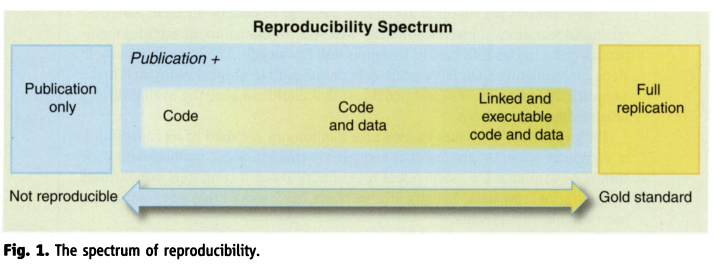

## Benefits

Using the R Notebook also makes it easier to double check so that errors are avoided. It is also simpler to get the result confirmed.

Using R Notebook and R markdown one can convert the article into html, PDF, Word formats e.t.c. with the help of `pandoc`. One can also use it with knitr that is a good tool to use with analyses involving statistics.

[figure not shown]

As mentioned above, we use reproducibility to repeat a research using the same data but with a separate twist.

Although a test is reproducible, the quality of the research might not be good.

## Disadvantages

An example: Some groups believes reproducibility means repeating an investigation in an article using the same data, and replicability means doing it again, preferably with new data, but getting the same response. While other groups believe the opposite.

There is also another minus with reproducibility and that is that the result you have obtained can be built on by others who in turn can use it to develop new ideas or other methods. It may lead to further errors if the article was initially incorrect.

## Solution

First of all, a solution could be that the scientific environment came together to create and definition to each of the different concepts reproducibility, replicability, reliability, robustness, and generalizability. It would have made the concepts easier to use and which in turn had given a common understanding of what was used at any given time. Goodman, Fanelli, and Ioannidis (2016) want to divide it into three different elements: methods reproducibility, results reproducibility, and inferential repro- ducibility. For their part, it is mostly for use in the biomedical field, but there is great faith that this could also solve other scientific areas.

Bollen et al. (2015) write that scientists should document all the information in the procedures they use when collecting data - right down to the level of detail. It will make it easier and more effective for researchers who comes after using the same report and get the same results as the original researchers. It will not only reproduce reproducibility, but they will also be able to provide more information.

## Is there a perfect code?

Barnes (2010) claims that researchers don’t have to put so much emphasis on coding in their work, because the benefit of sharing raw data can be greater than writing a perfect code.

He further writes that if we share raw data that performs the job it is supposed to, the intention with the data is in place. So why not share it then.

He points out that in 2007 NASA released a software that wasn’t completely finished, but by releasing it before it was completely finished, they received help along the way so that it became both better and more user-friendly. Even if they got help, it didn’t mean that NASA had released a bad program or that the result after they released the first version gave a slightly worse result. NASA took the changes with them and made the software even better.

In conclusion, he writes that researchers must work together to create space to release raw data, so that we can benefit from each others help and not always strive for perfectionism before we publish. But this is not something researchers can do alone, they need help from the community around them (Barnes 2010).

### **Code Chunk**

Chunk is a feature that can be used to more easily get information about the study. It can show when the study was made and which packages were used. It is important for reproducibility that the next scientist receives as much information as possible about the study so that he can use the same data.

# References

Barnes, Nick. 2010. “Publish Your Computer Code: It Is Good Enough.” *Nature* 467 (7317): 753–53. https://doi.org/10.1038/467753a.

Bollen, Kenneth, John T. Cacioppo, Jon A. Krosnick, James L. Olds, and Robert M. Kaplan. 2015. “Social, Behavioral, and Economic Sciences Perspectives on Robust and Reliable Science.” Report of the Subcommittee on Replicability in Science Advisory Committee to the National Science Foundation Directorate for Social, Behavioral, and Economic Sciences. NSF.

Goodman, Steven N., Daniele Fanelli, and John P. A. Ioannidis. 2016. “What Does Research Reproducibility Mean?” *Science Translational Medicine* 8 (341): 341ps12–12. https://doi.org/10.1126/scitranslmed.aaf5027.

Grolemund, Garrett, J. J. Allaire. n.d. *R Markdown: The Definitive Guide*. Accessed September 15, 2021. https://bookdown.org/yihui/rmarkdown/.

Lander, Jared P. 2017. *R for Everyone: Advanced Analytics and Graphics*. 2nd Edition. Boston: Addison-Wesley Professional.

Picture 1 Roger Peng.PNG

Picture 2 rmarkdown_workflow.png

# Appendix

[figure not shown]